# PML Course Project

Gaël Bonnardot

23 août 2015

## 1) Exploratory Analysis

To get to know the data a bit better I used, dim(), head() and str() functions on the training data.

```r
setwd("C:/Users/G/Documents/R")
set.seed(3456)
training<-read.csv("pml-training.csv")
dim(training)
```

```
## [1] 19622   160
```

The data is relatively big: 19622 observations of 160 variables. Variable types are mainly numeric, integer and factors. There are 5 levels to the factor ‘classe’ that we wish to predict: {A,B,C,D,E}. As described on the website http://groupware.les.inf.puc-rio.br/har the classes correspond to different type of postures and movements, class A being the right posture to perform the Unilateral Dumbbell Biceps Curl exercise.

Here is the structure of the data:

Captors:

- Belt
- Arm
- Dumbbell
- Forearm

Raw Data (19216 observations):

- Pitch
- Yaw
- Roll
- Total Acceleration
- Gyros (X,Y,Z)
- Acceleration (X,Y,Z)
- Magnet (X,Y,Z)

Summary Data (406 windows):

- Kurtosis
- Skewness
- Maximum
- Minimum
- Standard Deviation
- Variance
- Amplitude

Variable “cvtd_timestamp” tells us that the data was taken on 4 different days: 11/28/2011, 11/30/2011, 12/02/2011, 12/05/2011. We will assume that the data is not dependent on which day the sample is made. It could be worth checking if the results vary depending on what time of the day it is executed : we can imagine motion amplitude being smaller towards the end of the day.

Of the 19622 observations 19216 are raw data and 406 are aggregated data which correspond to all the raw data contained in the 406 windows. A smaller number of variables sum up the raw data information: minimum, maximum values, standard deviation, variance, average, kurtosis, skewness. However this is the case for pitch, yaw and roll measures and not for gyro, acceleration and magnet measures.

Since the test set consists of point observations and not aggregated data on a whole window we will concentrate the training on the observation data.

```r
train1<-training[!complete.cases(training),]
train1<-train1[,c(8:11,37:49,60:68,84:86,102,113:124,140,151:160)]
dim(train1)
```

```
## [1] 19216    53
```

This leaves us with 52 variables, which is still an important number.

## 2) Preprocessing

### 2.1) Dummy Variables

As all of the 52 potential predictors are of type numeric or integer so no dummy variable needs to be created.

### 2.2) Near Zero/Zero Variance Predictors

Using function nearZeroVar() we confirm that none of the 52 predictors have zero or near zero variance.

```r
library(caret)
nearZeroVar(train1)
```

```
## integer(0)
```

### 2.3) Identifying Correlated Predictors

Using function findCorrelation in the correlation matrix of the 52 predictors with cutoff 0.75 we remove 21 of the predictors, leaving us with 31 of the predictors, we will call the resulting training set train1.

```r
descrCor<-cor(train1[,-53])
highlyCorDescr<-findCorrelation(descrCor, cutoff = .75)
train1<-train1[,-highlyCorDescr]
dim(train1)
```

```
## [1] 19216    32
```

### 2.4) d. Principal Component Analysis

```r
## PCA
#
train2<-training[!complete.cases(training),]
train2<-train2[,c(8:11,37:49,60:68,84:86,102,113:124,140,151:160)]
#
# beltv=train2[,c(1:13)]
# pcabelt<-PCA(beltv,graph=FALSE)
# pcabelt$eig
# pcabelt$var$coord
#
# armv<-train2[,c(14:26)]
# pcaarm<-PCA(armv,graph=FALSE)
# pcaarm$eig
# pcaarm$var$coord
#
# dumbbellv<-train2[,c(27:39)]
# pcadumbbell<-PCA(dumbbellv,graph=FALSE)
# pcadumbbell$eig
# pcadumbbell$var$coord
#
# forearmv<-train2[,c(40:52)]
# pcaforearm<-PCA(forearmv,graph=FALSE)
# pcaforearm$eig
# pcaforearm$var$coord'
```

```r
train2<-train2[,c(1:3,10,13,17,19,21,25:27,29,31,35:36,45,48:51,53)]
```

## 4) Modelling

### 4.1) Decision Tree (“Rpart” Method)

```r
modFit<-train(classe~.,method="rpart",data=train2)
```

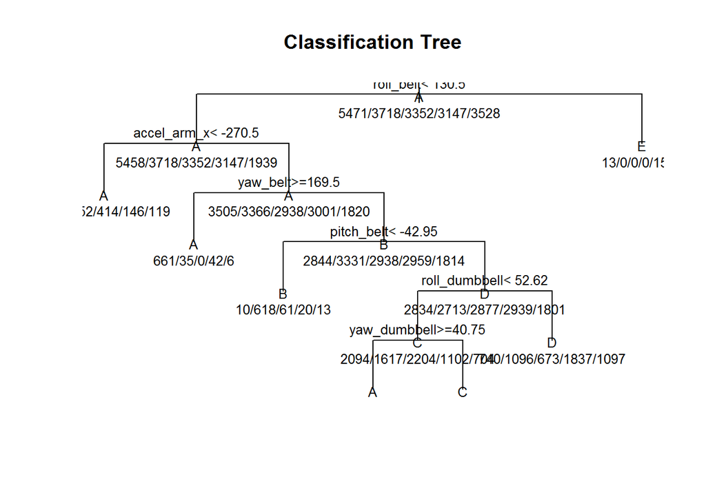

```r
plot(modFit$finalModel,uniform=TRUE,main="Classification Tree")
text(modFit$finalModel,use.n=TRUE,all=TRUE,cex=.8)
```

```r
print(modFit)
```

```
## CART
##
## 19216 samples
##    20 predictor
##     5 classes: 'A', 'B', 'C', 'D', 'E'
##
## No pre-processing
## Resampling: Bootstrapped (25 reps)
## Summary of sample sizes: 19216, 19216, 19216, 19216, 19216, 19216, ...
## Resampling results across tuning parameters:
##
##   cp          Accuracy   Kappa      Accuracy SD  Kappa SD
##   0.03215715  0.4908873  0.3346600  0.06460477   0.10777705
##   0.03301200  0.4644064  0.2911074  0.07590628   0.12752846
##   0.11465988  0.3213301  0.0548611  0.04253164   0.06320232
##
## Accuracy was used to select the optimal model using  the largest value.
## The final value used for the model was cp = 0.03215715.
```

The Decision Tree on its own does not yield any interesting result, as expected.

### 4.2) Random Forests (“RF” Method)

```r
#modFit2<-train(classe~.,data=train2,method="rf",prox=TRUE)
```

I have found that given the number of variables and observations Random Forests performs slowly compared to Boosting, computation time was too long on my computer (4GB RAM, 64bit).

### 4.3) Boosting (“GBM” Method)

```r
#modFitBoost<-train(classe~.,method="gbm",data=train2,trControl=fitControl1,verbose=FALSE)
```

Resampling results across tuning parameters: